# Visualizing Time Series Data in Python

Time series data is omnipresent in the field of Data Science. Whether it is analyzing business trends, forecasting company revenue or exploring customer behavior, every data scientist is likely to encounter time series data at some point during their work. To get you started on working with time series data, this course will provide practical knowledge on visualizing time series data using Python.

The data set that we are going to use in the course:

- [Inventions and Scientific Discoveries](https://assets.datacamp.com/production/repositories/1259/datasets/580f81133e1aa0803bdd2adda1670b4efff9778a/ch1_discoveries.csv)
- [CO2 levels in Mauai Hawaii](https://assets.datacamp.com/production/repositories/1259/datasets/88073ba2ec84224b732314d97b9862b049930f32/ch2_co2_levels.csv)
- [Airline passengers](https://assets.datacamp.com/production/repositories/1259/datasets/f8f1084c73032207abfc6b8a2499cab410bcfd62/ch3_airline_passengers.csv)
- [Production of meat in USA](https://assets.datacamp.com/production/repositories/1259/datasets/1e1cd4384a858ebd0a47d995bb0b963bfee09afd/ch4_meat.csv)
- [Unemployment rate in USA](https://assets.datacamp.com/production/repositories/1259/datasets/1c6b4a977a3c14f2a00c2d74694b208d9ac86443/ch5_employment.csv)

```python
import pandas as pd
import numpy as np
import matplotlib.pyplot as plt
import seaborn as sns

from statsmodels.graphics import tsaplots
# Import statsmodels.api as sm
import statsmodels.api as sm
```

## 1. Line Plots

We will learn how to leverage basic plottings tools in Python, and how to annotate and personalize our time series plots. By the end of this chapter, we will be able to take any static dataset and produce compelling plots of our data.

```python
# Read in the file content in a DataFrame called discoveries
url_discoveries = 'https://assets.datacamp.com/production/repositories/1259/datasets/580f81133e1aa0803bdd2adda1670b4efff9778a/ch1_discoveries.csv'
discoveries = pd.read_csv(url_discoveries)
# discoveries.to_csv("data_2/discoveries.csv")

# Display the first five lines of the DataFrame
print(discoveries.head())
```

```
         date  Y
0  01-01-1860  5
1  01-01-1861  3
2  01-01-1862  0
3  01-01-1863  2
4  01-01-1864  0
```

```python
# Print the data type of each column in discoveries
print(discoveries.dtypes)
print("#"*40)

# Convert the date column to a datestamp type
discoveries['date'] = pd.to_datetime(discoveries['date'])

# Print the data type of each column in discoveries, again
print(discoveries.dtypes)
```

```
date    object
Y        int64
dtype: object
########################################
date    datetime64[ns]
Y                int64
dtype: object
```

Next, we will set the groundwork by producing a time series plot of our data and labeling the axes of our plot, as this makes the plot more readable and interpretable for the intended audience.

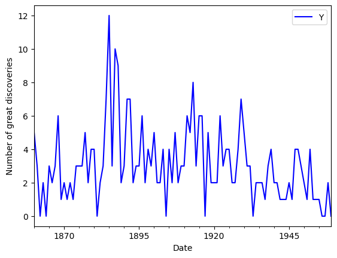

```python
# Set the date column as the index of your DataFrame discoveries
discoveries = discoveries.set_index('date')

# Plot the time series in your DataFrame
ax = discoveries.plot(color='blue')

# Specify the x-axis label in your plot
ax.set_xlabel('Date')

# Specify the y-axis label in your plot
ax.set_ylabel('Number of great discoveries')

# Show plot
plt.show()
```

It looks like the largest number of great discoveries happened during the year of 1885.

The matplotlib library also comes with a number of built-in stylesheets that allow us to customize the appearance of our plots. To use a particular style sheet for our plots, we can use the command `plt.style.use(your_stylesheet)` where `your_stylesheet` is the name of the style sheet.

In order to see the list of available style sheets that can be used, we can use the command `print(plt.style.available)`. For the rest of this course, we will use the `fivethirtyeight` style sheet.

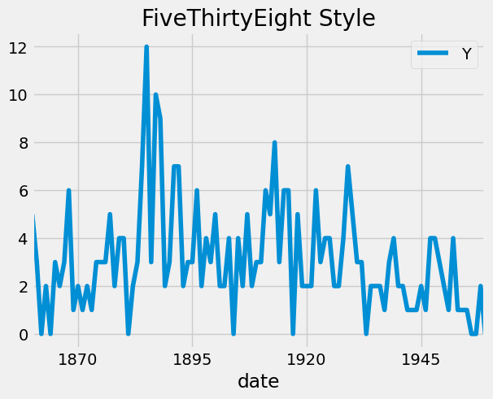

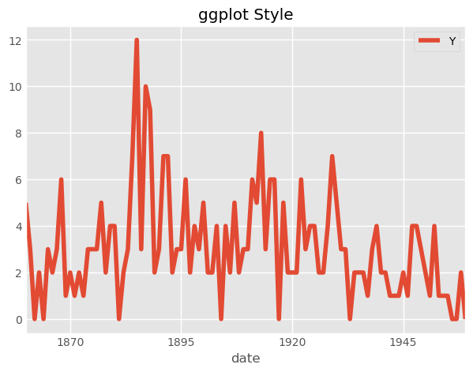

```python
# Use the fivethirtyeight style
plt.style.use('fivethirtyeight')

# Plot the time series
ax1 = discoveries.plot()
ax1.set_title('FiveThirtyEight Style')
plt.show()

# Use the ggplot style
ax2 = plt.style.use('ggplot')
ax2 = discoveries.plot()

# Set the title
ax2.set_title('ggplot Style')
plt.show()
```

As we saw earlier, if the index of a pandas DataFrame consists of dates, then pandas will automatically format the x-axis in a human-readable way. In addition the `.plot()` method allows us to specify various other parameters to tailor our time series plot (color of the lines, width of the lines and figure size).

You may have noticed the use of the notation `ax = df.plot(...)` and wondered about the purpose of the `ax` object. This is because the `plot` function returns a `matplotlib` `AxesSubplot` object, and it is common practice to assign this returned object to a variable called `ax`. Doing so also allows us to include additional notations and specifications to our plot such as axis labels.

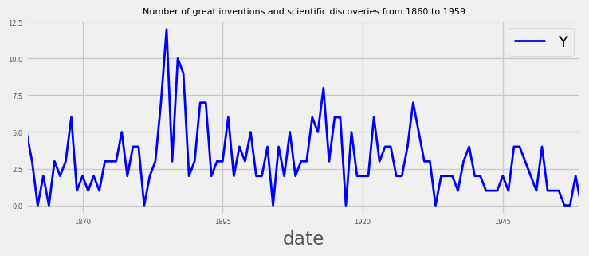

```python
# Use the fivethirtyeight style
plt.style.use('fivethirtyeight')

# Plot a line chart of the discoveries DataFrame using the specified arguments
ax = discoveries.plot(color='blue', figsize=(8, 3), linewidth=2, fontsize=6)

# Specify the title in your plot
ax.set_title('Number of great inventions and scientific discoveries from 1860 to 1959', fontsize=8)

# Show plot
plt.show()
```

When plotting time series data, we may occasionally want to visualize only a subset of the data. The `pandas` library provides powerful indexing and subsetting methods that allow us to extract specific portions of a DataFrame. For example, we can subset all the data between 1950 and 1960 in the `discoveries` DataFrame by specifying the following date range: `subset_data = discoveries['1950-01-01':'1960-01-01']`.

**Note**: Subsetting our data this way is only possible if the index of our DataFrame contains dates of the `datetime` type.

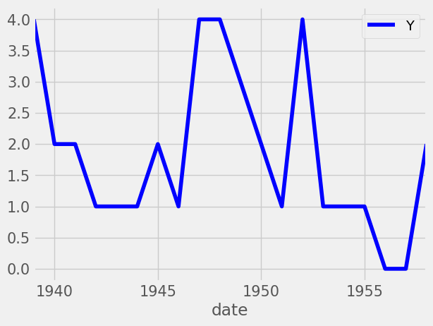

```python
# Select the subset of data between 1945 and 1950
discoveries_subset_1 = discoveries['1939-1-1':'1958-1-1']

# Plot the time series in your DataFrame as a blue area chart
ax = discoveries_subset_1.plot(color='blue', fontsize=15)

# Show plot
plt.show()
```

Additional annotations can help further emphasize specific observations or events. Here, we will learn how to highlight significant events by adding markers at specific timestamps of our time series plot. The `matplotlib` library makes it possible to draw vertical and horizontal lines to identify particular dates.

Recall that the index of the `discoveries` DataFrame are of the `datetime` type, so the x-axis values of a plot will also contain dates, and it is possible to directly input a date when annotating our plots with vertical lines. For example, a vertical line at January 1, 1945 can be added to our plot by using the command: `ax.axvline('1945-01-01', linestyle='--')`.

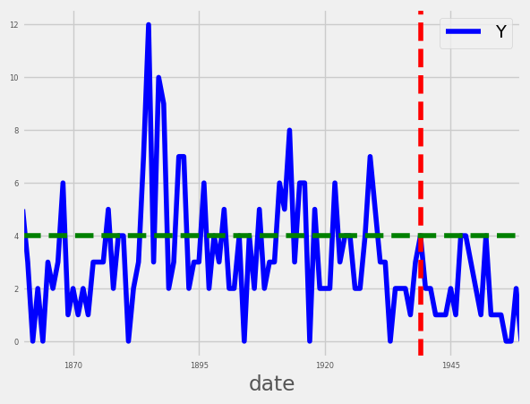

```python
# Plot your the discoveries time series
ax = discoveries.plot(color='blue', fontsize=6)

# Add a red vertical line
ax.axvline('1939-01-01', color='red', linestyle='--')

# Add a green horizontal line
ax.axhline(4, color='green', linestyle='--')

plt.show()
```

Adding vertical and horizontal markers to a graph is a powerful feature, so hopefully it will be helpful to us!

When plotting time series data in Python, it is also possible to highlight complete regions of our time series plot. In order to add a shaded region between January 1, 1936 and January 1, 1950, we can use the command: `ax.axvspan('1936-01-01', '1950-01-01', color='red' , alpha=0.5)`.

Here we specified the overall transparency of the region by using the `alpha` argument (where `0` is completely transparent and `1` is full color).

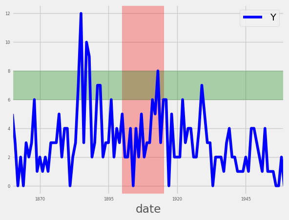

```python
# Plot your the discoveries time series
ax = discoveries.plot(color='blue', fontsize=6)

# Add a vertical red shaded region
ax.axvspan('1900-01-01', '1915-01-01', color='red', alpha=0.3)

# Add a horizontal green shaded region
ax.axhspan(6, 8, color='green', alpha=0.3)

plt.show()
```

## 2. Summary Statistics and Diagnostics

In this chapter, we will gain a deeper understanding of our time series data by computing summary statistics and plotting aggregated views of your data.

#### Clean your time series data

In the field of Data Science, it is common to encounter datasets with missing values. This is especially true in the case of time series data, where missing values can occur if a measurement fails to record the value at a specific timestamp. To count the number of missing values in a DataFrame called `df` that contains time series data, we can use the command: `missing_values = df.isnull().sum()`.

```python
# Read in the file content in a DataFrame called discoveries
url_co2_levels = 'https://assets.datacamp.com/production/repositories/1259/datasets/88073ba2ec84224b732314d97b9862b049930f32/ch2_co2_levels.csv'
co2_levels = pd.read_csv(url_co2_levels)
# co2_levels.to_csv("data_2/co2_levels.csv")

# Display first seven rows of co2_levels
print(co2_levels.head(7))
```

```
    datestamp    co2
0  1958-03-29  316.1
1  1958-04-05  317.3
2  1958-04-12  317.6
3  1958-04-19  317.5
4  1958-04-26  316.4
5  1958-05-03  316.9
6  1958-05-10    NaN
```

```python
# Set datestamp column as index
co2_levels = co2_levels.set_index('datestamp')

# Print out the number of missing values
print(co2_levels.isnull().sum())
```

```
co2    59
dtype: int64
```

It looks like the `co2_levels` DataFrame contains missing values, let's see how we can handle those!

In order to replace missing values in our time series data, we can use the command: `df = df.fillna(method="ffill")`, where the argument specifies the type of method we want to use. For example, specifying `bfill` (i.e backfilling) will ensure that missing values are replaced using the next valid observation, while `ffill` (i.e. forward-filling) ensures that missing values are replaced using the last valid observation.

```python
# Impute missing values with the next valid observation
co2_levels = co2_levels.fillna(method='bfill')

# Print out the number of missing values
print(co2_levels.isnull().sum())
```

```
co2    0
dtype: int64
```

#### Plot aggregates of your data

It is also possible to visualize rolling averages of the values in our time series. This is equivalent to "smoothing" the data, and can be particularly useful when our time series contains a lot of noise or outliers. For a given DataFrame `df`, we can obtain the rolling average of the time series by using the command: `df_mean = df.rolling(window=12).mean()`.

The `window` parameter should be set according to the granularity of our time series. For example, if our time series contains daily data and we are looking for rolling values over a whole year, we should specify the parameter to `window=365`. In addition, it is easy to get rolling values for other other metrics, such as the standard deviation (`.std()`) or variance (`.var()`).

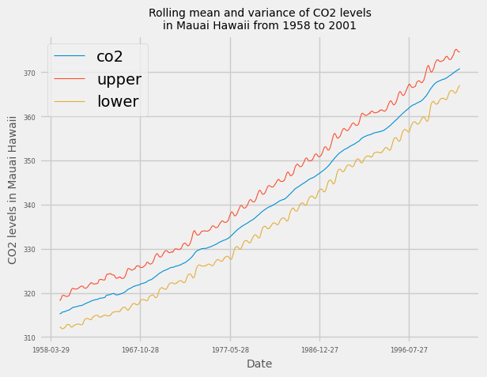

```python
# Compute the 52 weeks rolling mean of the co2_levels DataFrame
ma = co2_levels.rolling(window=52).mean()

# Compute the 52 weeks rolling standard deviation of the co2_levels DataFrame
mstd = co2_levels.rolling(window=52).std()

# Add the upper bound column to the ma DataFrame
ma['upper'] = ma['co2'] + (2 * mstd['co2'])

# Add the lower bound column to the ma DataFrame
ma['lower'] = ma['co2'] - (2 * mstd['co2'])

# Plot the content of the ma DataFrame
ax = ma.plot(linewidth=0.8, fontsize=6)

# Specify labels, legend, and show the plot
ax.set_xlabel('Date', fontsize=10)
ax.set_ylabel('CO2 levels in Mauai Hawaii', fontsize=10)
ax.set_title('Rolling mean and variance of CO2 levels\nin Mauai Hawaii from 1958 to 2001', fontsize=10)
plt.show()
```

Showing the rolling mean and standard deviation of our data allows to get a more compact view of our data.

We may sometimes be required to display our data in a more aggregated form. For example, the `co2_levels` data contains weekly data, but we may need to display its values aggregated by month of year. In datasets such as the `co2_levels` DataFrame where the index is a `datetime` type, we can extract the year of each dates in the index: `index_year = df.index.year`.

To extract the month or day of the dates in the indices of the `df` DataFrame, we would use `df.index.month` and `df.index.day`, respectively. We can then use the extracted year of each indices in the `co2_levels` DataFrame and the `groupby` function to compute the mean CO2 levels by year: `df_by_year = df.groupby(index_year).mean()`.

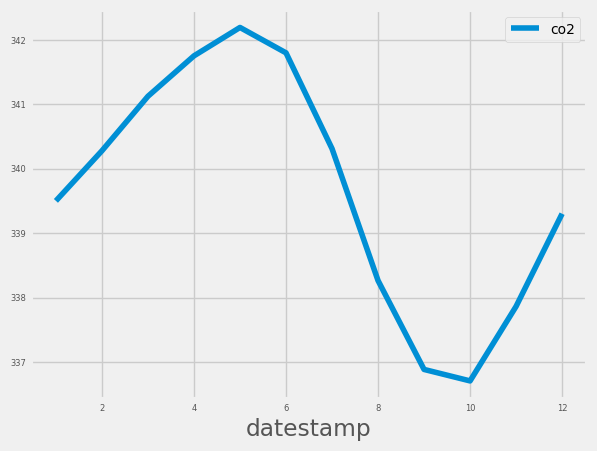

```python
# Get month for each dates in the index of co2_levels
co2_levels.index = pd.to_datetime(co2_levels.index)

# Get month for each dates in the index of co2_levels
index_month = co2_levels.index.month

# Compute the mean CO2 levels for each month of the year
mean_co2_levels_by_month = co2_levels.groupby(index_month).mean()

# Plot the mean CO2 levels for each month of the year
mean_co2_levels_by_month.plot(fontsize=6)

# Specify the fontsize on the legend
plt.legend(fontsize=10)

# Show plot
plt.show()
```

#### Summarize the values in our time series data

We have learnt how to display and annotate time series data in multiple ways, but it is also informative to collect summary statistics of the data. Being able to achieve this task will allow us to share and discuss statistical properties of our data that can further support the plots we generate. In pandas, it is possible to quickly obtain summaries of columns in our DataFrame by using the command: `print(df.describe())`. This will print statistics including the mean, the standard deviation, the minima and maxima and the number of observations for all numeric columns in our `pandas` DataFrame.

```python
# Print out summary statistics of the co2_levels DataFrame
print(co2_levels.describe())

# Print out the minima of the co2 column in the co2_levels DataFrame
print(co2_levels['co2'].min())

# Print out the maxima of the co2 column in the co2_levels DataFrame
print(co2_levels['co2'].max())
```

```
               co2
count  2284.000000
mean    339.657750
std      17.100899
min     313.000000
25%     323.975000
50%     337.700000
75%     354.500000
max     373.900000
313.0
373.9
```

Boxplots represent a graphical rendition of the minimum, median, quartiles, and maximum of our data. We can generate a boxplot by calling the `.boxplot()` method on a DataFrame.

Another method to produce visual summaries is by leveraging histograms, which allow us to inspect the data and uncover its underlying distribution, as well as the presence of outliers and overall spread. An example of how to generate a histogram: `ax = co2_levels.plot(kind='hist', bins=100)`. Here, we used the standard `.plot()` method but specified the `kind` argument to be `'hist'`. In addition, we also added the `bins=100` parameter, which specifies how many intervals (i.e bins) we should cut our data into.

```
No artists with labels found to put in legend.  Note that artists whose label start with an underscore are ignored when legend() is called with no argument.
```

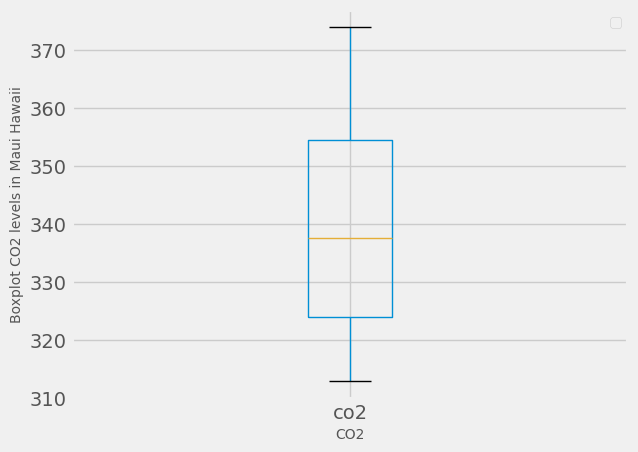

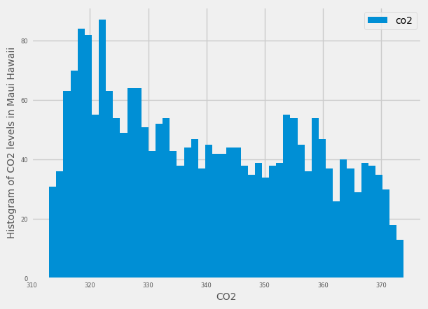

```python
# Generate a boxplot
ax = co2_levels.boxplot()

# Set the labels and display the plot
ax.set_xlabel('CO2', fontsize=10)
ax.set_ylabel('Boxplot CO2 levels in Maui Hawaii', fontsize=10)
plt.legend(fontsize=10)
plt.show()

# Generate a histogram
ax = co2_levels.plot(kind='hist', bins=50, fontsize=6)

# Set the labels and display the plot
ax.set_xlabel('CO2', fontsize=10)
ax.set_ylabel('Histogram of CO2 levels in Maui Hawaii', fontsize=10)
plt.legend(fontsize=10)
plt.show()
```

In practice, histograms can be a substandard method for assessing the distribution of our data because they can be strongly affected by the number of bins that have been specified. Instead, kernel density plots represent a more effective way to view the distribution of our data. An example of how to generate a density plot: `ax = df.plot(kind='density', linewidth=2)`. The standard `.plot()` method is specified with the `kind` argument set to `'density'`. We also specified an additional parameter `linewidth`, which controls the width of the line to be plotted.

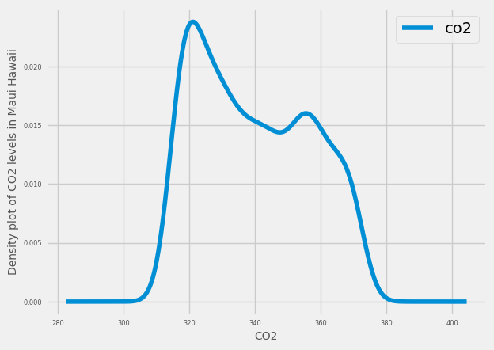

```python
# Display density plot of CO2 levels values
ax = co2_levels.plot(kind='density', linewidth=4, fontsize=6)

# Annotate x-axis labels
ax.set_xlabel('CO2', fontsize=10)

# Annotate y-axis labels
ax.set_ylabel('Density plot of CO2 levels in Maui Hawaii', fontsize=10)

plt.show()
```

## 3. Seasonality, Trend and Noise

We will go beyond summary statistics by learning about autocorrelation and partial autocorrelation plots. We will also learn how to automatically detect seasonality, trend and noise in our time series data.

#### [Autocorrelation and Partial Autocorrelation](https://towardsdatascience.com/a-step-by-step-guide-to-calculating-autocorrelation-and-partial-autocorrelation-8c4342b784e8)

In the field of time series analysis, **autocorrelation** refers to the correlation of a time series with a lagged version of itself. For example, an autocorrelation of `order 3` returns the correlation between a time series and its own values lagged by 3 time points.

It is common to use the autocorrelation (ACF) plot, also known as self-autocorrelation, to visualize the autocorrelation of a time-series. The `plot_acf()` function in the`statsmodels` library can be used to measure and plot the autocorrelation of a time series.

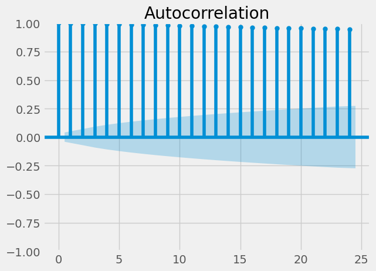

```python
plt.style.use('fivethirtyeight')

# Display the autocorrelation plot of your time series
fig = tsaplots.plot_acf(co2_levels['co2'], lags=24)

# Show plot
plt.show()
```

Autocorrelation plots can be used to quickly discover patterns into our time series.

If autocorrelation values are close to 0, then values between consecutive observations are not correlated with one another. Inversely, autocorrelations values close to 1 or -1 indicate that there exists strong positive or negative correlations between consecutive observations, respectively. In order to help us asses how trustworthy these autocorrelation values are, the `plot_acf()` function also returns confidence intervals (represented as blue shaded regions). If an autocorrelation value goes beyond the confidence interval region, we can assume that the observed autocorrelation value is statistically significant. Based on the plot above, we can say that the `co2_levels` observations are highly correlated and statistically significant.

Like autocorrelation, the partial autocorrelation function (PACF) measures the correlation coefficient between a time-series and lagged versions of itself. However, it extends upon this idea by also removing the effect of previous time points. For example, a partial autocorrelation function of order 3 returns the correlation between our time series (`t_1`, `t_2`, `t_3`, …) and its own values lagged by 3 time points (`t_4`, `t_5`, `t_6`, …), but only after removing all effects attributable to lags 1 and 2.

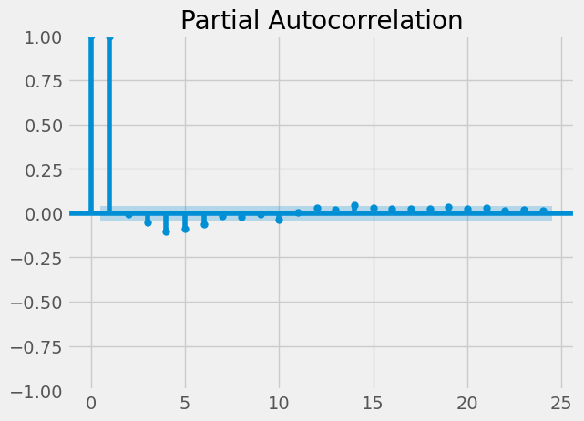

```python
# Display the partial autocorrelation plot of your time series
fig = tsaplots.plot_pacf(co2_levels['co2'], lags=24)

# Show plot
plt.show()
```

Just like autocorrelation, partial autocorrelation plots can be tricky to interpret.

If partial autocorrelation values are close to 0, then values between observations and lagged observations are not correlated with one another. Inversely, partial autocorrelations with values close to 1 or -1 indicate that there exists strong positive or negative correlations between the lagged observations of the time series.

The `.plot_pacf()` function also returns confidence intervals, which are represented as blue shaded regions. If partial autocorrelation values are beyond this confidence interval regions, we you can assume that the observed partial autocorrelation values are statistically significant. Based on the plot above, we can say that the lag values of 0, 1, 4, 5 and 6 are statistically significant partial autocorrelations.

#### Seasonality, trend and noise in time series data

When visualizing time series data, we should look out for some distinguishable patterns:

- **seasonality:** does the data display a clear periodic pattern?
- **trend:** does the data follow a consistent upwards or downward slope?
- **noise:** are there any outlier points or missing values that are not consistent with the rest of the data?

We can rely on a method known as time-series decomposition to automatically extract and quantify the structure of time-series data. The `statsmodels` library provides the `seasonal_decompose()` function to perform time series decomposition out of the box.

`decomposition = sm.tsa.seasonal_decompose(time_series)`

We can extract a specific component, for example seasonality, by accessing the `seasonal` attribute of the decomposition object.

```python
# Perform time series decompositon
decomposition = sm.tsa.seasonal_decompose(co2_levels)

# Print the seasonality component
print(decomposition.seasonal)
```

```
datestamp
1958-03-29    1.028042
1958-04-05    1.235242
1958-04-12    1.412344
1958-04-19    1.701186
1958-04-26    1.950694
                ...
2001-12-01   -0.525044
2001-12-08   -0.392799
2001-12-15   -0.134838
2001-12-22    0.116056
2001-12-29    0.285354
Name: seasonal, Length: 2284, dtype: float64
```

Time series decomposition is a powerful method to reveal the structure of our time series. Now let's visualize these components.

It is also possible to extract other inferred quantities from our time-series decomposition object. The following code shows how to extract the observed, trend and noise (or residual, `resid`) components.

- `observed = decomposition.observed`
- `trend = decomposition.trend`
- `residuals = decomposition.resid`

We can then use the extracted components and plot them individually.

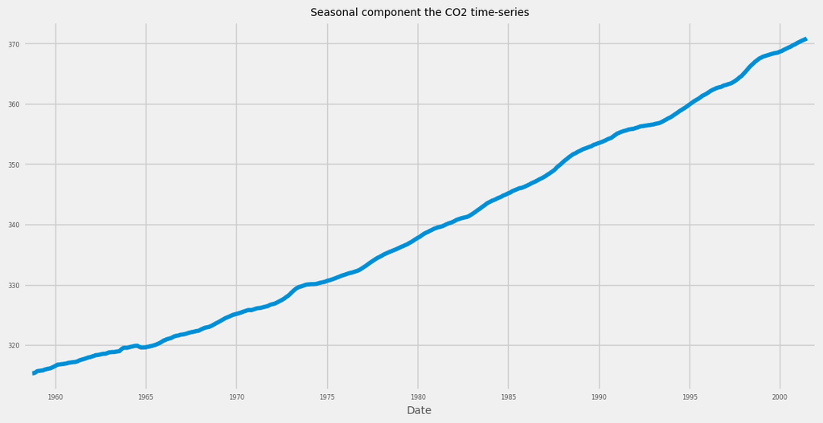

```python
# Extract the trend component
trend = decomposition.trend

# Plot the values of the trend
ax = trend.plot(figsize=(12, 6), fontsize=6)

# Specify axis labels
ax.set_xlabel('Date', fontsize=10)
ax.set_title('Seasonal component the CO2 time-series', fontsize=10)
plt.show()
```

#### A quick review

We will now review the contents of chapter 1. We will have the opportunity to work with a new dataset that contains the monthly number of passengers who took a commercial flight between January 1949 and December 1960.

```python
# Read in the file content in a DataFrame called discoveries
url_airline = 'https://assets.datacamp.com/production/repositories/1259/datasets/f8f1084c73032207abfc6b8a2499cab410bcfd62/ch3_airline_passengers.csv'
airline = pd.read_csv(url_airline)
# airline.to_csv("data_2/airline.csv")

# Display first seven rows of co2_levels
print(airline.head())
```

```
     Month  AirPassengers
0  1949-01            112
1  1949-02            118
2  1949-03            132
3  1949-04            129
4  1949-05            121
```

```python
# Set Month column as index
airline = airline.set_index('Month')
airline.index = pd.to_datetime(airline.index)
```

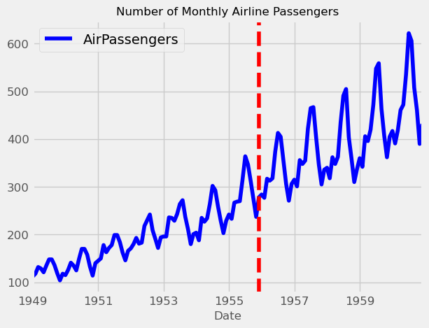

```python
# Plot the time series in your DataFrame
ax = airline.plot(color='blue', fontsize=12)

# Add a red vertical line at the date 1955-12-01
ax.axvline('1955-12-01', color='red', linestyle='--')

# Specify the labels in your plot
ax.set_xlabel('Date', fontsize=12)
ax.set_title('Number of Monthly Airline Passengers', fontsize=12)
plt.show()
```

The number of airline passengers has risen a lot over time. Can we find any interesting patterns in this time series?

In Chapter 2 we learned:

- How to check for the presence of missing values, and how to collect summary statistics of time series data contained in a `pandas` DataFrame.
- To generate boxplots of our data to quickly gain insight in our data.
- Display *aggregate* statistics of your data using `groupby()`.

In this exercise, we will apply all these concepts on the `airline` DataFrame.

```
AirPassengers    0
dtype: int64
       AirPassengers
count     144.000000
mean      280.298611
std       119.966317
min       104.000000
25%       180.000000
50%       265.500000
75%       360.500000
max       622.000000
```

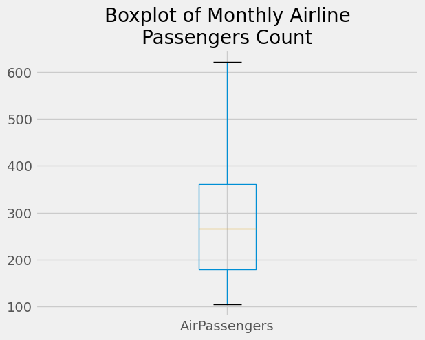

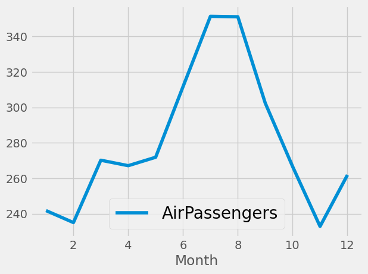

```python
# Print out the number of missing values
print(airline.isna().sum())

# Print out summary statistics of the airline DataFrame
print(airline.describe())

# Display boxplot of airline values
ax = airline.boxplot()

# Specify the title of your plot
ax.set_title('Boxplot of Monthly Airline\nPassengers Count', fontsize=20)
plt.show()

# Get month for each dates from the index of airline
index_month = airline.index.month

# Compute the mean number of passengers for each month of the year
mean_airline_by_month = airline.groupby(index_month).mean()

# Plot the mean number of passengers for each month of the year
mean_airline_by_month.plot()
plt.legend(fontsize=20)
plt.show()
```

Looks like July and August are the busiest months!

In final exercise, we will apply time series decomposition to the `airline` dataset, and visualize the `trend` and `seasonal` components.

```
            trend   seasonal
Month
1949-01-01    NaN -24.748737
1949-02-01    NaN -36.188131
1949-03-01    NaN  -2.241162
1949-04-01    NaN  -8.036616
1949-05-01    NaN  -4.506313
```

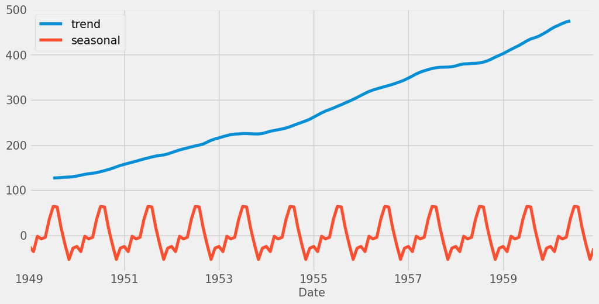

```python
# Perform time series decompositon
decomposition = sm.tsa.seasonal_decompose(airline)

# Extract the trend and seasonal components
trend = decomposition.trend
seasonal = decomposition.seasonal

airline_decomposed = pd.concat([trend, seasonal], axis=1)

# Print the first 5 rows of airline_decomposed
print(airline_decomposed.head())

# Plot the values of the airline_decomposed DataFrame
ax = airline_decomposed.plot(figsize=(12, 6), fontsize=15)

# Specify axis labels
ax.set_xlabel('Date', fontsize=15)
plt.legend(fontsize=15)
plt.show()
```

## 4. Work with Multiple Time Series

In the field of Data Science, it is common to be involved in projects where multiple time series need to be studied simultaneously. In this chapter, we will show how to plot multiple time series at once, and how to discover and describe relationships between multiple time series.

#### Working with more than one time series

Whether it is during personal projects or our day-to-day work as a Data Scientist, it is likely that we will encounter situations that require the analysis and visualization of multiple time series at the same time.

Provided that the data for each time series is stored in distinct columns of a file, the pandas library makes it easy to work with multiple time series. In the following exercises, we will work with a new time series dataset that contains the amount of different types of meat produced in the USA between 1944 and 2012.

```python
# Read in the file content in a DataFrame called discoveries
url_meat = 'https://assets.datacamp.com/production/repositories/1259/datasets/1e1cd4384a858ebd0a47d995bb0b963bfee09afd/ch4_meat.csv'
meat = pd.read_csv(url_meat)
# meat.to_csv("data_2/meat.csv")

# Display first seven rows of co2_levels
print(meat.head())
```

```
         date   beef   veal    pork  lamb_and_mutton  broilers  other_chicken  \
0  1944-01-01  751.0   85.0  1280.0             89.0       NaN            NaN
1  1944-02-01  713.0   77.0  1169.0             72.0       NaN            NaN
2  1944-03-01  741.0   90.0  1128.0             75.0       NaN            NaN
3  1944-04-01  650.0   89.0   978.0             66.0       NaN            NaN
4  1944-05-01  681.0  106.0  1029.0             78.0       NaN            NaN

   turkey
0     NaN
1     NaN
2     NaN
3     NaN
4     NaN
```

```python
# Set date column as index
meat = meat.set_index('date')
meat.index = pd.to_datetime(meat.index)

# Print the summary statistics of the DataFrame
print(meat.describe())
```

```
              beef        veal         pork  lamb_and_mutton     broilers  \
count   827.000000  827.000000   827.000000       827.000000   635.000000
mean   1683.463362   54.198549  1211.683797        38.360701  1516.582520
std     501.698480   39.062804   371.311802        19.624340   963.012101
min     366.000000    8.800000   124.000000        10.900000   250.900000
25%    1231.500000   24.000000   934.500000        23.000000   636.350000
50%    1853.000000   40.000000  1156.000000        31.000000  1211.300000
75%    2070.000000   79.000000  1466.000000        55.000000  2426.650000
max    2512.000000  215.000000  2210.400000       109.000000  3383.800000

       other_chicken      turkey
count     143.000000  635.000000
mean       43.033566  292.814646
std         3.867141  162.482638
min        32.300000   12.400000
25%        40.200000  154.150000
50%        43.400000  278.300000
75%        45.650000  449.150000
max        51.100000  585.100000
```

If there are multiple time series in a single DataFrame, we can still use the `.plot()` method to plot a line chart of all the time series. Another interesting way to plot these is to use area charts. Area charts are commonly used when dealing with multiple time series, and can be used to display cumulated totals.

With the `pandas` library, we can simply leverage the `.plot.area()` method to produce area charts of the time series data in our DataFrame.

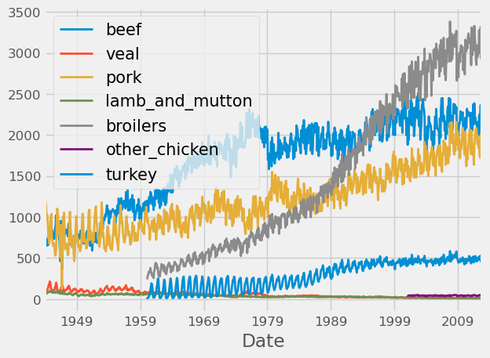

```python
# Plot time series dataset
ax = meat.plot(linewidth=2, fontsize=12)

# Additional customizations
ax.set_xlabel('Date')
ax.legend(fontsize=15)

# Show plot
plt.show()
```

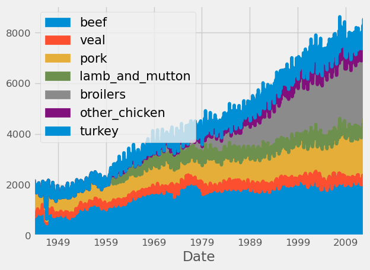

```python
# Plot an area chart
ax = meat.plot.area(fontsize=12)

# Additional customizations
ax.set_xlabel('Date')
ax.legend(fontsize=15)

# Show plot
plt.show()
```

It looks the time series in the `meat` DataFrame have very different growth rates!

#### Plot multiple time series

When visualizing multiple time series, it can be difficult to differentiate between various colors in the default color scheme.

To remedy this, we can define each color manually, but this may be time-consuming. Fortunately, it is possible to leverage the `colormap` argument to `.plot()` to automatically assign specific color palettes with varying contrasts. We can either provide a `matplotlib colormap` as an input to this parameter, or provide one of the default strings that is available in the `colormap()` function available in matplotlib (all of which are available [here](https://matplotlib.org/2.0.2/examples/color/colormaps_reference.html)).

For example, we can specify the `viridis` colormap using the following command: `df.plot(colormap='viridis')`.

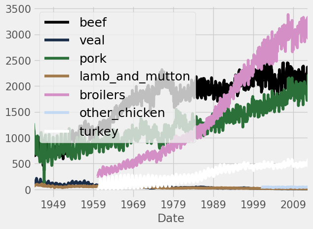

```python
# Plot time series dataset using the cubehelix color palette
ax = meat.plot(colormap='cubehelix', fontsize=15)

# Additional customizations
ax.set_xlabel('Date')
ax.legend(fontsize=18)

# Show plot
plt.show()
```

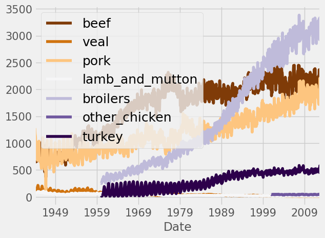

```python
# Plot time series dataset using the PuOr color palette
ax = meat.plot(colormap='PuOr', fontsize=15)

# Additional customizations
ax.set_xlabel('Date')
ax.legend(fontsize=18)

# Show plot
plt.show()
```

It is possible to visualize time series plots and numerical summaries on one single graph by using the `pandas` API to `matplotlib` along with the `table` method:

```
# Plot the time series data in the DataFrame`
ax = df.plot()

# Compute summary statistics of the df DataFrame
df_summary = df.describe()

# Add summary table information to the plot
ax.table(cellText=df_summary.values,
         colWidths=[0.3]*len(df.columns),
         rowLabels=df_summary.index,
         colLabels=df_summary.columns,
         loc='top')
```

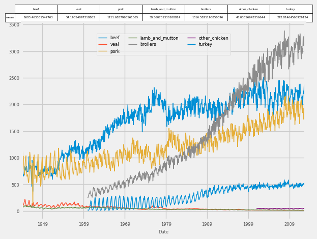

```python
meat_mean = meat.describe().loc['mean'].to_frame().transpose()

# Plot the meat data
ax = meat.plot(fontsize=6, linewidth=1)

# Add x-axis labels
ax.set_xlabel('Date', fontsize=6)

# Add summary table information to the plot
ax.table(cellText=meat_mean.values,
         colWidths = [0.15]*len(meat_mean.columns),
         rowLabels=meat_mean.index,
         colLabels=meat_mean.columns,
         loc='top')

# Specify the fontsize and location of your legend
ax.legend(loc='upper center', bbox_to_anchor=(0.5, 0.95), ncol=3, fontsize=6)

# Show plot
plt.show()
```

It can be beneficial to plot individual time series on separate graphs as this may improve clarity and provide more context around each time series in our DataFrame.

It is possible to create a "grid" of individual graphs by "faceting" each time series by setting the `subplots` argument to `True`. In addition, the arguments that can be added are:

- `layout`: specifies the number of `rows x columns` to use.
- `sharex` and `sharey`: specifies whether the x-axis and y-axis values should be shared between our plots.

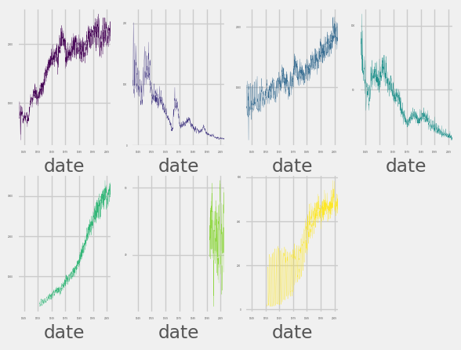

```python
# Create a facetted graph with 2 rows and 4 columns
meat.plot(subplots=True,
          layout=(2,4),
          sharex=False,
          sharey=False,
          colormap='viridis',
          fontsize=2,
          legend=False,
          linewidth=0.2)

plt.show()
```

#### Find relationships between multiple time series

The correlation coefficient can be used to determine how multiple variables (or a group of time series) are associated with one another. The result is a correlation matrix that describes the correlation between time series. Note that the diagonal values in a correlation matrix will always be 1, since a time series will always be perfectly correlated with itself.

Correlation coefficients can be computed with the pearson, kendall and spearman methods. A full discussion of these different methods is outside the scope of this course, but the pearson method should be used when relationships between our variables are thought to be linear, while the kendall and spearman methods should be used when relationships between our variables are thought to be non-linear.

```python
# Print the correlation matrix between the beef and pork columns using the spearman method
print(meat[['beef', 'pork']].corr(method='spearman'))
print('#'*40)

# Print the correlation between beef and pork columns
print(meat[['beef', 'pork']].corr(method='spearman').loc['pork','beef'])
print('#'*40)

# Compute the correlation between the pork, veal and turkey columns using the pearson method
print(meat[['pork', 'veal', 'turkey']].corr(method='pearson'))
```

```
          beef      pork
beef  1.000000  0.827587
pork  0.827587  1.000000
########################################
0.8275872847134006
########################################
            pork      veal    turkey
pork    1.000000 -0.808834  0.835215
veal   -0.808834  1.000000 -0.768366
turkey  0.835215 -0.768366  1.000000
```

The correlation matrix generated in the previous exercise can be plotted using a heatmap. To do so, we can leverage the `heatmap()` function from the `seaborn` library which contains several arguments to tailor the look of your heatmap.

```
df_corr = df.corr()

sns.heatmap(df_corr)
plt.xticks(rotation=90)
plt.yticks(rotation=0)
```

We can use the `.xticks()` and `.yticks()` methods to rotate the axis labels so they don't overlap.

To learn about the arguments to the `heatmap()` function, refer to this [page](https://seaborn.pydata.org/generated/seaborn.heatmap.html).

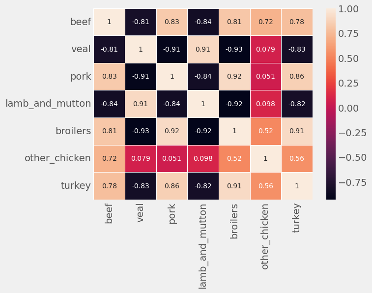

```python
# Get correlation matrix of the meat DataFrame: corr_meat
corr_meat = meat.corr(method='spearman')

# Customize the heatmap of the corr_meat correlation matrix
sns.heatmap(corr_meat,
            annot=True,
            linewidths=0.4,
            annot_kws={"size": 10})

plt.xticks(rotation=90)
plt.yticks(rotation=0)
plt.show()
```

Heatmaps are extremely useful to visualize a correlation matrix, but clustermaps are better. A Clustermap allows to uncover structure in a correlation matrix by producing a hierarchically-clustered heatmap:

```
df_corr = df.corr()

fig = sns.clustermap(df_corr)
plt.setp(fig.ax_heatmap.xaxis.get_majorticklabels(), rotation=90)
plt.setp(fig.ax_heatmap.yaxis.get_majorticklabels(), rotation=0)
```

To prevent overlapping of axis labels, we can reference the `Axes` from the underlying `fig` object and specify the rotation. We can learn about the arguments to the `clustermap()` function [here](https://seaborn.pydata.org/generated/seaborn.clustermap.html).

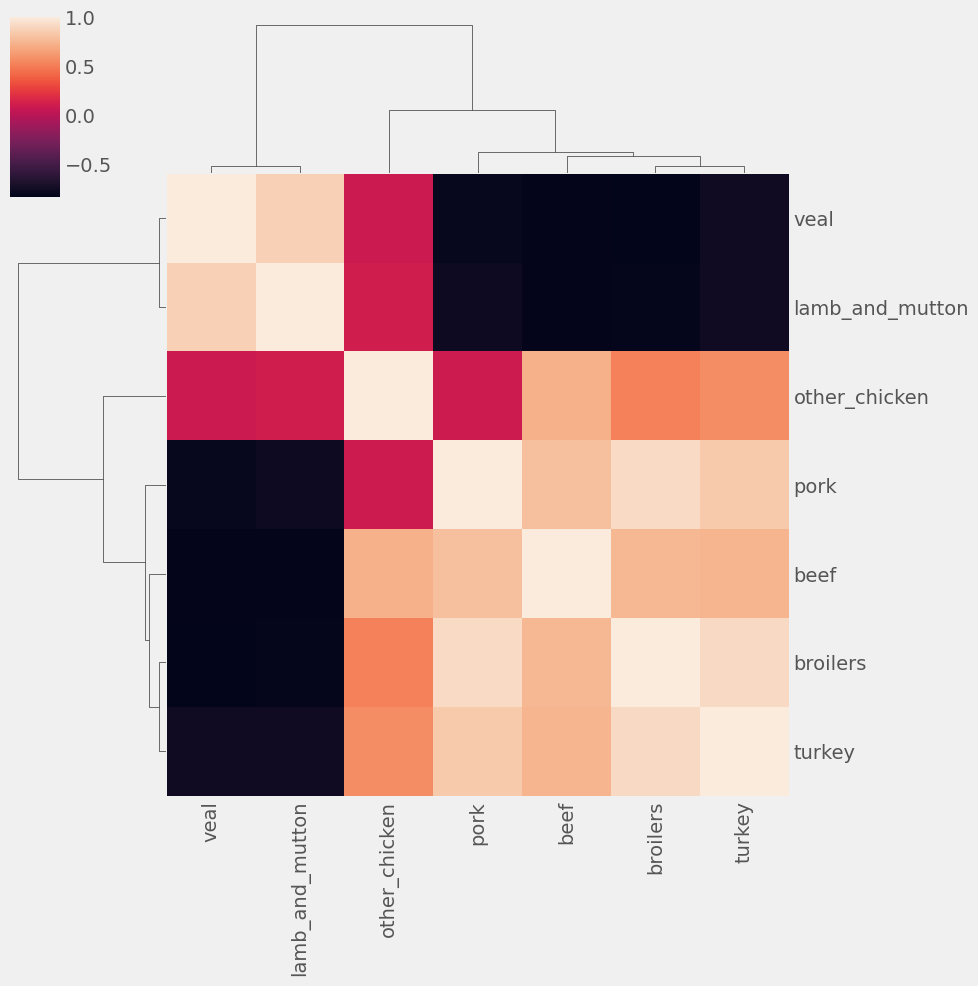

```python
# Get correlation matrix of the meat DataFrame
corr_meat = meat.corr(method='pearson')

# Customize the heatmap of the corr_meat correlation matrix and rotate the x-axis labels
fig = sns.clustermap(corr_meat,
                     row_cluster=True,
                     col_cluster=True,
                     figsize=(10, 10))

plt.setp(fig.ax_heatmap.xaxis.get_majorticklabels(), rotation=90)
plt.setp(fig.ax_heatmap.yaxis.get_majorticklabels(), rotation=0)
plt.show()
```

## 5. Case Study: Unemployment Rate

This chapter will give us a chance to practice all the concepts covered in the course. We will visualize the unemployment rate in the US from 2000 to 2010.

#### Apply your knowledge to a new dataset

In this exercise, we will explore the new `jobs` DataFrame, which contains the unemployment rate of different industries in the USA during the years of 2000-2010. As we will see, the dataset contains time series for 16 industries and across 122 timepoints (one per month for 10 years). In general, the typical workflow of a Data Science project will involve data cleaning and exploration, so we will begin by reading in the data and checking for missing values.

```python
# Read in the file content in a DataFrame called jobs
url_jobs = 'https://assets.datacamp.com/production/repositories/1259/datasets/1c6b4a977a3c14f2a00c2d74694b208d9ac86443/ch5_employment.csv'
jobs = pd.read_csv(url_jobs)
jobs.to_csv("data_2/jobs.csv")

# Check the type of each column in your DataFrame
print(jobs.dtypes)

# Display first rows of jobs
print(jobs.head())
```

```
datestamp                          object
Agriculture                       float64
Business services                 float64
Construction                      float64
Durable goods manufacturing       float64
Education and Health              float64
Finance                           float64
Government                        float64
Information                       float64
Leisure and hospitality           float64
Manufacturing                     float64
Mining and Extraction             float64
Nondurable goods manufacturing    float64
Other                             float64
Self-employed                     float64
Transportation and Utilities      float64
Wholesale and Retail Trade        float64
dtype: object
    datestamp  Agriculture  Business services  Construction  \
0  2000-01-01         10.3                5.7           9.7
1  2000-02-01         11.5                5.2          10.6
2  2000-03-01         10.4                5.4           8.7
3  2000-04-01          8.9                4.5           5.8
4  2000-05-01          5.1                4.7           5.0

   Durable goods manufacturing  Education and Health  Finance  Government  \
0                          3.2                   2.3      2.7         2.1
1                          2.9                   2.2      2.8         2.0
2                          2.8                   2.5      2.6         1.5
3                          3.4                   2.1      2.3         1.3
4                          3.4                   2.7      2.2         1.9

   Information  Leisure and hospitality  Manufacturing  Mining and Extraction  \
0          3.4                      7.5            3.6                    3.9
1          2.9                      7.5            3.4                    5.5
2          3.6                      7.4            3.6                    3.7
3          2.4                      6.1            3.7                    4.1
4          3.5                      6.2            3.4                    5.3

   Nondurable goods manufacturing  Other  Self-employed  \
0                             4.4    4.9            2.3
1                             4.2    4.1            2.5
2                             5.1    4.3            2.0
3                             4.0    4.2            2.0
4                             3.6    4.5            1.9

   Transportation and Utilities  Wholesale and Retail Trade
0                           4.3                         5.0
1                           4.0                         5.2
2                           3.5                         5.1
3                           3.4                         4.1
4                           3.4                         4.3
```

```python
# Set date column as index
jobs = jobs.set_index('datestamp')
jobs.index = pd.to_datetime(jobs.index)

# Check the number of missing values in each column
print(jobs.isnull().sum())
```

```
Agriculture                       0
Business services                 0
Construction                      0
Durable goods manufacturing       0
Education and Health              0
Finance                           0
Government                        0
Information                       0
Leisure and hospitality           0
Manufacturing                     0
Mining and Extraction             0
Nondurable goods manufacturing    0
Other                             0
Self-employed                     0
Transportation and Utilities      0
Wholesale and Retail Trade        0
dtype: int64
```

We should always explore the distribution of the variables, and because we are working with time series, we will explore their properties using boxplots and numerical summaries. As a reminder, we can plot data in a DataFrame as boxplots with the command:

```
df.boxplot(fontsize=6, vert=False)
```

Notice the introduction of the new parameter `vert`, which specifies whether to plot the boxplots horizontally or vertically.

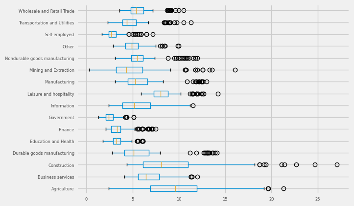

```
       Agriculture  Business services  Construction  \
count   122.000000         122.000000    122.000000
mean      9.840984           6.919672      9.426230
std       3.962067           1.862534      4.587619
min       2.400000           4.100000      4.400000
25%       6.900000           5.600000      6.100000
50%       9.600000           6.450000      8.100000
75%      11.950000           7.875000     10.975000
max      21.300000          12.000000     27.100000

       Durable goods manufacturing  Education and Health     Finance  \
count                   122.000000            122.000000  122.000000
mean                      6.025410              3.420492    3.540164
std                       2.854475              0.877538    1.235405
min                       2.800000              1.800000    2.100000
25%                       4.125000              2.900000    2.700000
50%                       5.100000              3.200000    3.300000
75%                       6.775000              3.700000    3.700000
max                      14.100000              6.100000    7.500000

       Government  Information  Leisure and hospitality  Manufacturing  \
count  122.000000   122.000000               122.000000     122.000000
mean     2.581148     5.486885                 8.315574       5.982787
std      0.686750     2.016582                 1.605570       2.484221
min      1.300000     2.400000                 5.900000       3.100000
25%      2.100000     3.900000                 7.300000       4.500000
50%      2.400000     5.150000                 8.050000       5.300000
75%      2.875000     6.900000                 8.800000       6.600000
max      5.100000    11.500000                14.200000      13.000000

       Mining and Extraction  Nondurable goods manufacturing       Other  \
count             122.000000                      122.000000  122.000000
mean                5.088525                        5.930328    5.096721
std                 2.942428                        1.922330    1.317457
min                 0.300000                        3.100000    2.900000
25%                 3.200000                        4.825000    4.200000
50%                 4.300000                        5.500000    4.900000
75%                 6.050000                        6.100000    5.600000
max                16.100000                       12.000000   10.000000

       Self-employed  Transportation and Utilities  Wholesale and Retail Trade
count     122.000000                    122.000000                  122.000000
mean        3.031967                      4.935246                    5.766393
std         1.124429                      1.753340                    1.463417
min         1.700000                      2.300000                    3.600000
25%         2.400000                      3.900000                    4.800000
50%         2.700000                      4.400000                    5.400000
75%         3.200000                      5.400000                    6.200000
max         7.200000                     11.300000                   10.500000
```

```python
# Generate a boxplot
jobs.boxplot(fontsize=6, vert=False)
plt.show()

# Generate numerical summaries
print(jobs.describe())
```

Looks like the time series in our data are pretty different to another, let's dig into this a bit more and plot them!

#### Beyond summary statistics

```
            Finance  Information  Manufacturing  Construction
datestamp
2000-01-01      2.7          3.4            3.6           9.7
2000-02-01      2.8          2.9            3.4          10.6
2000-03-01      2.6          3.6            3.6           8.7
2000-04-01      2.3          2.4            3.7           5.8
2000-05-01      2.2          3.5            3.4           5.0
```

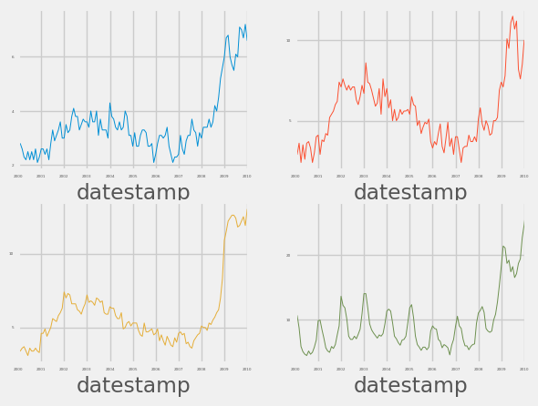

```python
# A subset of the jobs DataFrame
jobs_subset = jobs[['Finance', 'Information', 'Manufacturing', 'Construction']]

# Print the first 5 rows of jobs_subset
print(jobs_subset.head())

# Create a facetted graph with 2 rows and 2 columns
ax = jobs_subset.plot(subplots=True,
                      layout=(2,2),
                      sharex=False,
                      sharey=False,
                      linewidth=0.7,
                      fontsize=3,
                      legend=False)

plt.show()
```

The plots really show that there was a drastic increase in unemployment rate during in 2001 and 2008!

When plotting the `Finance`, `Information`, `Manufacturing` and `Construction` time series of the `jobs` DataFrame, we observed a distinct increase in unemployment rates during 2001 and 2008. In general, time series plots can be made even more informative if we include additional annotations that emphasize specific observations or events. This allows us to quickly highlight parts of the graph to viewers, and can help infer what may have caused a specific event.

Recall that we have already set the `datestamp` column as the index of the `jobs` DataFrame, so we are prepared to directly annotate our plots with vertical or horizontal lines.

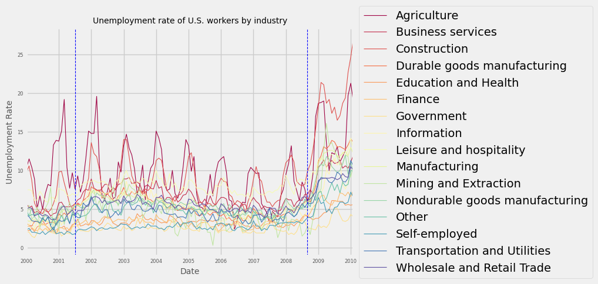

```python
# Plot all time series in the jobs DataFrame
ax = jobs.plot(colormap='Spectral', fontsize=6, linewidth=0.8)

# Set labels and legend
ax.set_xlabel('Date', fontsize=10)
ax.set_ylabel('Unemployment Rate', fontsize=10)
ax.set_title('Unemployment rate of U.S. workers by industry', fontsize=10)
ax.legend(loc='center left', bbox_to_anchor=(1.0, 0.5))

# Annotate your plots with vertical lines
ax.axvline('2001-07-01', color='blue', linestyle='--', linewidth=0.8)
ax.axvline('2008-09-01', color='blue', linestyle='--', linewidth=0.8)

# Show plot
plt.show()
```

Like we saw in Chapter 2, when the index of a DataFrame is of the `datetime` type, it is possible to directly extract the day, month or year of each date in the index. As a reminder, we can extract the year of each date in the index using the `.index.year` attribute. We can then use the `.groupby()` and `.mean()` methods to compute the mean annual value of each time series in our DataFrame:

```
index_year = df.index.year
df_by_year = df.groupby(index_year).mean()
```

We will now apply what we have learned to display the aggregate mean values of each time series in the `jobs` DataFrame.

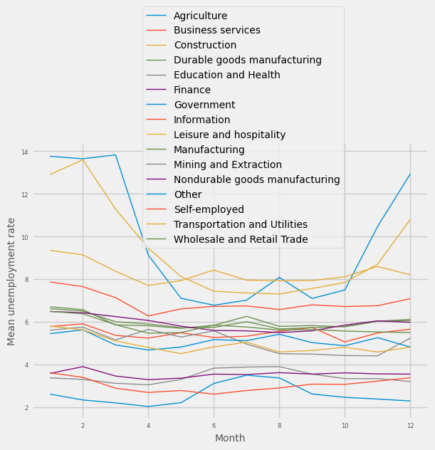

```python
# Extract the month from the index of jobs
index_month = jobs.index.month

# Compute the mean unemployment rate for each month
jobs_by_month = jobs.groupby(index_month).mean()

# Plot the mean unemployment rate for each month
ax = jobs_by_month.plot(fontsize=6, linewidth=1)

# Set axis labels and legend
ax.set_xlabel('Month', fontsize=10)
ax.set_ylabel('Mean unemployment rate', fontsize=10)
ax.legend(bbox_to_anchor=(0.8, 0.6), fontsize=10)
plt.show()
```

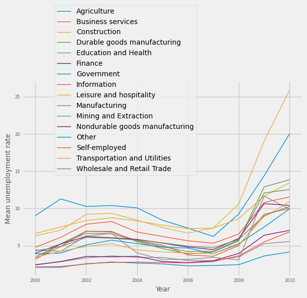

```python
# Extract of the year in each date indices of the jobs DataFrame
index_year = jobs.index.year

# Compute the mean unemployment rate for each year
jobs_by_year = jobs.groupby(index_year).mean()

# Plot the mean unemployment rate for each year
ax = jobs_by_year.plot(fontsize=6, linewidth=1)

# Set axis labels and legend
ax.set_xlabel('Year', fontsize=10)
ax.set_ylabel('Mean unemployment rate', fontsize=10)
ax.legend(bbox_to_anchor=(0.1, 0.5), fontsize=10)
plt.show()
```

Averaging time series values by month shows that unemployment rate tends to be a lot higher during the winter months for the Agriculture and Construction industry. The increase in unemployment rate after 2008 is very clear when average time series values by year.